# Synchrony Processing

- Show All Code
- Hide All Code
- View Source

# Overview

This is the second page of a three-page workflow examining **moment-to-moment dyadic dynamics in baseline couple interaction warmth**. It begins with the validated wide-format baseline warmth dataset created on the Import & Reliability page and prepares the second-by-second trajectories used in the synchrony analysis.

The processing workflow:

1. reshapes the wide SPSS file from one row per couple with one column per second into one row per couple-second;
2. recodes the missing-value placeholder to `NA`;
3. creates separate positive- and negative-discussion person-level long datasets for mom and partner;
4. saves the three analysis ready long files used by the synchrony calculation; and
5. plots warmth trajectories for the full sample and a representative subset as a visual data-quality and interpretive check.

**Workflow**

**1. Import & Reliability** → **2. Processing & Visualization** → **3. Synchrony Calculation**

Import & Reliability · Processing & Visualization · Synchrony Calculation

The preceding page documents the original CARMA import, validation, and reliability workflow: Import & Reliability. The next page uses the processed long-format files to calculate concurrent and time-lagged synchrony: Synchrony Calculation.

# Data Cleaning

**Load Packages**

```r
# Load packages used for reshaping, visualization, time-series analysis, modeling, and formatted output
library(here)
library(nlme)
library(tidyverse)
library(ggplot2)
library(lavaan)
library(semTools)
library(jtools)
library(haven)
library(modsem)
library(forecast)
library(gt)
```

## Transformation

The raw file has one row per couple and separate columns for each second of the interaction (e.g. `blmnwh.6`, `blmnwh.7`, …). This section reshapes that into a single long-format table (one row per couple-second), recodes the dataset’s missing-value placeholder to `NA`, and then splits the negative- and positive-discussion variables into their own person-level long datasets for plotting and later synchrony calculation.

**Reshape Wide to Long**

```r
# Transform data wide to long
BL_WH_WidetoLong <- BL_WH %>%
  pivot_longer(
    # Select columns like blmnwh.6, blmnwh.7, etc
    cols = matches("^[^.]+\\.\\d+$"),

    # Split variable name based on period
    names_to = c(".value", "second"),
    names_sep = "\\." ) %>%

  # Convert second to numeric
  mutate(second = as.numeric(second))
```

**Recode Missing Values**

```r
# Select the four warmth variables, second, ID
BL_WH_Long <- BL_WH_WidetoLong %>%
  select(ID, second, blmnwh, blmpwh, blfnwh, blfpwh)

# Set 0 as missing
BL_WH_Long$blmnwh[BL_WH_Long$blmnwh == 0] <- NA
BL_WH_Long$blmpwh[BL_WH_Long$blmpwh == 0] <- NA
BL_WH_Long$blfnwh[BL_WH_Long$blfnwh == 0] <- NA
BL_WH_Long$blfpwh[BL_WH_Long$blfpwh == 0] <- NA
```

```r
# echo: false

knitr::kable(
  head(BL_WH_Demo_Long, 5),
  caption = "Long Baseline Warmth Data (Demo)")
```

Long Baseline Warmth Data (Demo)

| ID | second | blmnwh | blmpwh | blfnwh | blfpwh |
| --- | --- | --- | --- | --- | --- |
| 123 | 6 | 4 | 5 | 3 | 3 |
| 123 | 7 | 7 | 4 | 4 | 7 |
| 123 | 8 | 4 | 7 | 1 | 2 |
| 123 | 9 | 7 | 6 | 3 | 1 |
| 123 | 10 | 1 | 5 | 3 | 7 |

**Create Negative Interaction Dataset**

```r
# Create long format for negative interaction
# (Blmnwh = mom, blfnwh = partner)

BL_WH_Neg_Long <- BL_WH_Long %>%
  select(ID, second, blmnwh, blfnwh) %>%
  tidyr::pivot_longer(
    cols = c(blmnwh, blfnwh),
    names_to = "source",
    values_to = "blnwh") %>%
  mutate(
    personF = case_when(
      source == "blmnwh" ~ "mom",  # Mom
      source == "blfnwh" ~ "partner" ),  # Partner
    personN = case_when(
      source == "blmnwh" ~ 1,  # Mom
      source == "blfnwh" ~ 2 ))  # Partner

# Set personF as factor
BL_WH_Neg_Long$personF <- as.factor(BL_WH_Neg_Long$personF)

# Set personN as factor
BL_WH_Neg_Long$personN <- as.numeric(BL_WH_Neg_Long$personN)
```

Long Baseline Warmth Negative Interaction Data (Demo)

| ID | second | source | blnwh | personF | personN |
| --- | --- | --- | --- | --- | --- |
| 123 | 6 | blmnwh | 4 | mom | 1 |
| 123 | 6 | blfnwh | 3 | partner | 2 |
| 123 | 7 | blmnwh | 7 | mom | 1 |
| 123 | 7 | blfnwh | 4 | partner | 2 |
| 123 | 8 | blmnwh | 4 | mom | 1 |
| 123 | 8 | blfnwh | 1 | partner | 2 |
| 123 | 9 | blmnwh | 7 | mom | 1 |
| 123 | 9 | blfnwh | 3 | partner | 2 |
| 123 | 10 | blmnwh | 1 | mom | 1 |
| 123 | 10 | blfnwh | 3 | partner | 2 |
| 123 | 11 | blmnwh | 1 | mom | 1 |
| 123 | 11 | blfnwh | 4 | partner | 2 |
| 123 | 12 | blmnwh | 6 | mom | 1 |
| 123 | 12 | blfnwh | 5 | partner | 2 |
| 123 | 13 | blmnwh | 4 | mom | 1 |
| 123 | 13 | blfnwh | 2 | partner | 2 |
| 123 | 14 | blmnwh | 4 | mom | 1 |
| 123 | 14 | blfnwh | 1 | partner | 2 |
| 123 | 15 | blmnwh | 5 | mom | 1 |
| 123 | 15 | blfnwh | 2 | partner | 2 |

**Create Positive Interaction Dataset**

```r
# Create long format for positive interaction
# (Blmpwh = mom, blfpwh = partner)

BL_WH_Pos_Long <- BL_WH_Long %>%
  select(ID, second, blmpwh, blfpwh) %>%
  tidyr::pivot_longer(
    cols = c(blmpwh, blfpwh),
    names_to = "source",
    values_to = "blpwh") %>%
  mutate(
    personF = case_when(
      source == "blmpwh" ~ "mom",  # Mom
      source == "blfpwh" ~ "partner" ),  # Partner
    personN = case_when(
      source == "blmpwh" ~ 1,  # Mom
      source == "blfpwh" ~ 2 ))  # Partner

# Set personF as factor
BL_WH_Pos_Long$personF <- as.factor(BL_WH_Pos_Long$personF)

# Set personN as factor
BL_WH_Pos_Long$personN <- as.numeric(BL_WH_Pos_Long$personN)
```

Long Baseline Warmth Positive Interaction Data (Demo)

| ID | second | source | blpwh | personF | personN |
| --- | --- | --- | --- | --- | --- |
| 123 | 6 | blmpwh | 5 | mom | 1 |
| 123 | 6 | blfpwh | 3 | partner | 2 |
| 123 | 7 | blmpwh | 4 | mom | 1 |
| 123 | 7 | blfpwh | 7 | partner | 2 |
| 123 | 8 | blmpwh | 7 | mom | 1 |
| 123 | 8 | blfpwh | 2 | partner | 2 |
| 123 | 9 | blmpwh | 6 | mom | 1 |
| 123 | 9 | blfpwh | 1 | partner | 2 |
| 123 | 10 | blmpwh | 5 | mom | 1 |
| 123 | 10 | blfpwh | 7 | partner | 2 |
| 123 | 11 | blmpwh | 1 | mom | 1 |
| 123 | 11 | blfpwh | 3 | partner | 2 |
| 123 | 12 | blmpwh | 1 | mom | 1 |
| 123 | 12 | blfpwh | 3 | partner | 2 |
| 123 | 13 | blmpwh | 5 | mom | 1 |
| 123 | 13 | blfpwh | 7 | partner | 2 |
| 123 | 14 | blmpwh | 7 | mom | 1 |
| 123 | 14 | blfpwh | 7 | partner | 2 |
| 123 | 15 | blmpwh | 7 | mom | 1 |
| 123 | 15 | blfpwh | 3 | partner | 2 |

The three long-format datasets are saved in a hidden export chunk so the visible page stays focused on transformation and quality checks while the Synchrony Calculation page can read the exact processed files produced here.

## Panel Plots

The two figures below show second-by-second warmth trends for the full sample, split by person (mom vs. partner) and by discussion type (negative vs. positive). The two figures after that repeat the same comparison for a representative subset of couples, faceted individually, so that couple-level variation around the sample trend is visible rather than smoothed away.

**Warmth During Negative Discussion**

**figure code**

```r
# Plot all negative-discussion warmth trajectories to inspect dyad-level patterns and potential data anomalies
fig_blnegative_warmth <- ggplot(data = BL_WH_Neg_Long, aes(second, blnwh, color = personF)) +
  geom_smooth(linewidth = 1.5) +
  scale_color_manual(values = c("mom" = "#CC6677", "partner" = "#88CCEE"), name = "Person") +
  labs(title = "Couple Warmth During Negative Discussion") +
  xlab("Time") +
  ylab("Average Warmth") +
  theme_minimal(base_size = 16) +
  theme(legend.position = "bottom", plot.title = element_text(face = "bold"),
        axis.title = element_text(size = 16), axis.text = element_text(size = 14),
        panel.grid = element_blank())
```

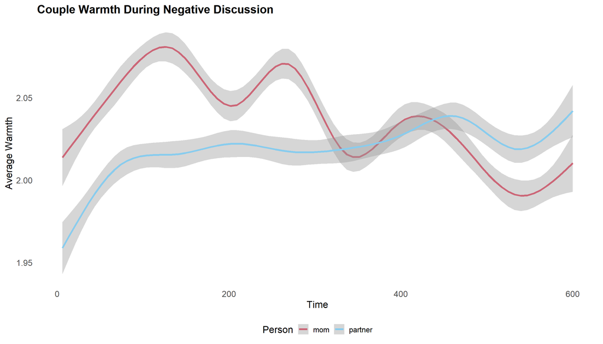

Figure 1

**figure code**

```r
# Plot all positive-discussion warmth trajectories to inspect dyad-level patterns and potential data anomalies
fig_blpositive_warmth <- ggplot(data = BL_WH_Pos_Long, aes(second, blpwh, color = personF)) +
  geom_smooth(linewidth = 1.5) +
  scale_color_manual(values = c("mom" = "#CC6677", "partner" = "#88CCEE"), name = "Person") +
  labs(title = "Couple Warmth During Positive Discussion") +
  xlab("Seconds") +
  ylab("Average Warmth") +
  theme_minimal(base_size = 16) +
  theme(legend.position = "bottom", plot.title = element_text(face = "bold"),
        axis.title = element_text(size = 16), axis.text = element_text(size = 14),
        panel.grid = element_blank())
```

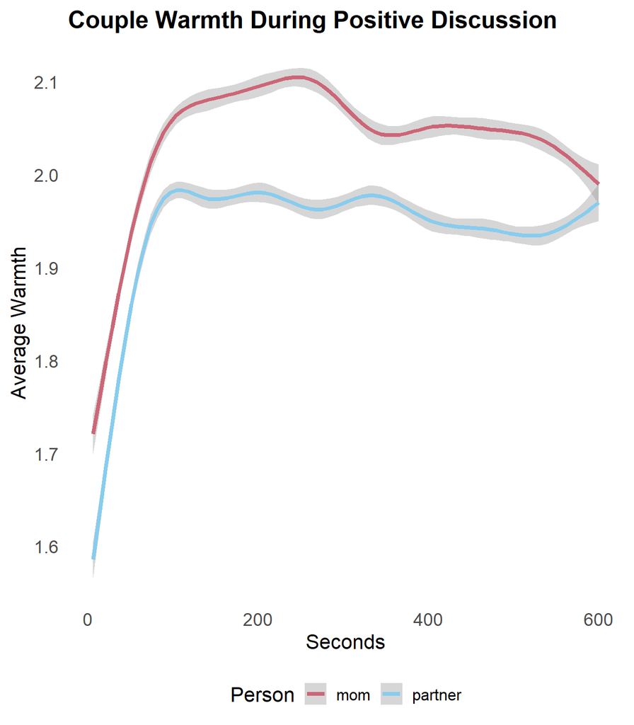

Figure 2

**figure code**

```r
# Plot a smaller negative-discussion subset so within-couple temporal patterns remain visually interpretable
fig_blnegative_warmth_subset <- ggplot(data = BL_WH_Neg_Long_Filtered, aes(second, blnwh, color = personF)) +
  geom_line(lwd = 1.5) +
  scale_color_manual(values = c("mom" = "#CC6677", "partner" = "#88CCEE"), name = "Person") +
  labs(title = "Couple Warmth During Negative Discussion (Sample Couples)") +
  xlab("Time - 0 to 600 seconds") +
  ylab("No (1) to High Warmth (7)") +
  facet_wrap(
    ~ ID,
    ncol = 3,
    labeller = labeller(ID = sample_id_map)) +
  theme_minimal(base_size = 16) +
  theme(legend.position = "bottom", plot.title = element_text(face = "bold"),
        axis.title = element_text(size = 16), axis.text = element_text(size = 14),
        panel.grid = element_blank())
```

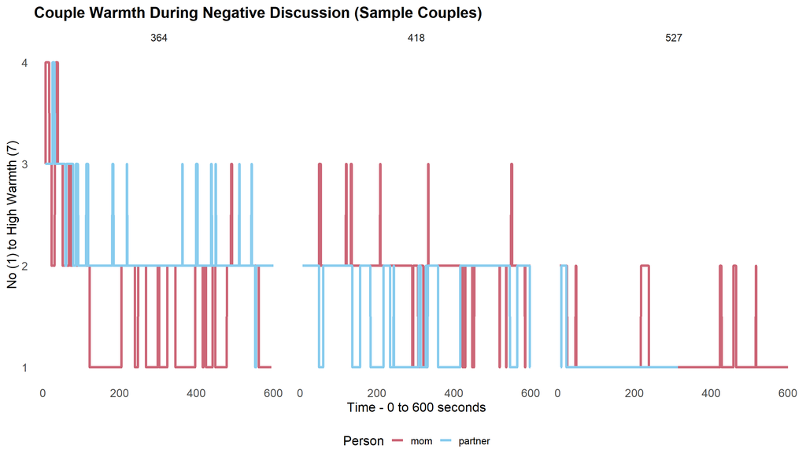

Figure 3

```r
# Plot a smaller positive-discussion subset so within-couple temporal patterns remain visually interpretable
fig_blpositive_warmth_subset <- ggplot(data = BL_WH_Pos_Long_Filtered, aes(second, blpwh, color = personF)) +  geom_line(lwd = 1.5) +
  scale_color_manual(values = c("mom" = "#CC6677", "partner" = "#88CCEE"), name = "Person") +
  labs(title = "Couple Warmth During Positive Discussion (Sample Couples)") +
  xlab("Time - 0 to 600 seconds") +
  ylab("No (1) to High Warmth (7)") +
  facet_wrap(
    ~ ID,
    ncol = 3,
    labeller = labeller(ID = sample_id_map)) +
  theme_minimal(base_size = 16) +
  theme(legend.position = "bottom", plot.title = element_text(face = "bold"),
        axis.title = element_text(size = 16), axis.text = element_text(size = 14),
        panel.grid = element_blank())
```

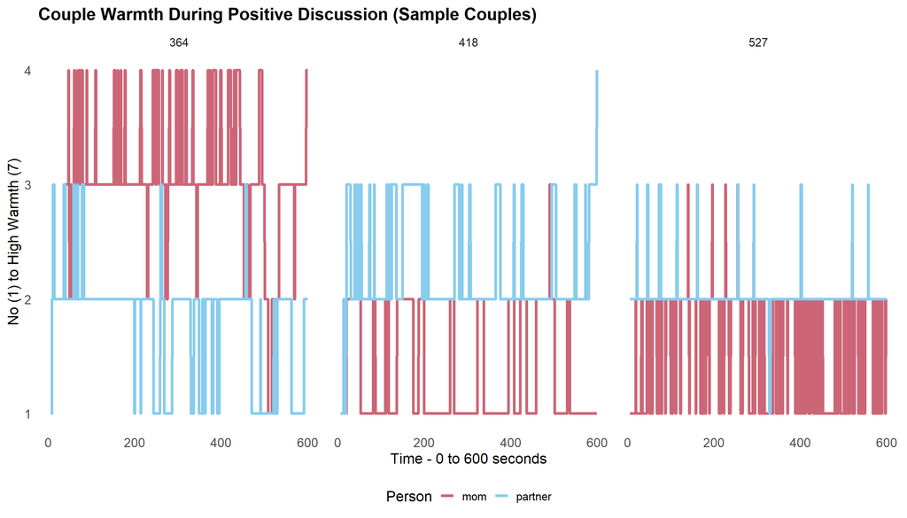

Figure 4

Back to top